# Chocolate

### Overview

**Context**

Chocolate is one of the most popular candies in the world. Each year, residents of the United States collectively eat more than 2.8 billion pounds. However, not all chocolate bars are created equal! This dataset contains expert ratings of over 1,700 individual chocolate bars, along with information on their regional origin, percentage of cocoa, the variety of chocolate bean used and where the beans were grown.

**Flavors of Cacao Rating System:**

- 5= Elite (Transcending beyond the ordinary limits)
- 4= Premium (Superior flavor development, character and style)
- 3= Satisfactory(3.0) to praiseworthy(3.75) (Well made with special qualities)
- 2= Disappointing (Passable but contains at least one significant flaw)
- 1= Unpleasant (mostly unpalatable)

The four countries that act as the base for the most chocolate manufaturers are listed in this table:

```r
choc <- read.csv("../Data/Chocolate.csv",header=TRUE, stringsAsFactors = FALSE)
mychoc <- subset(choc, Location %in% c("U.S.A.","Canada","U.K.","France"))
mychoc$Location <- as.factor(mychoc$Location)
pander(table(mychoc$Location), caption = "Number of Chocolate Manufacturers from each Country")
```

Number of Chocolate Manufacturers from each Country

| Canada | France | U.K. | U.S.A. |
| --- | --- | --- | --- |
| 124 | 156 | 96 | 764 |

**The Study**

Is there a difference in the quality of the chocolate between these countries?

### To Critiquers

Dear Critiquer,

There are a lot more countries than the four I chose. But these are the largest four.

Tell me if there is something I can do to make this study better.

### Analysis

#### Inference

Even though chocolate quality varies between different bars, can we find a difference between the top four manufacturing countries?

$${ H }_{ 0 }:\text{Every sample of chocolate bars from each country is taken from the same quality distribution.}\\ { H }_{ a }:\text{Not every sample of chocolate bars from each country is taken from the same quality distribution.}$$

#### Initial Sample Distribution Analysis

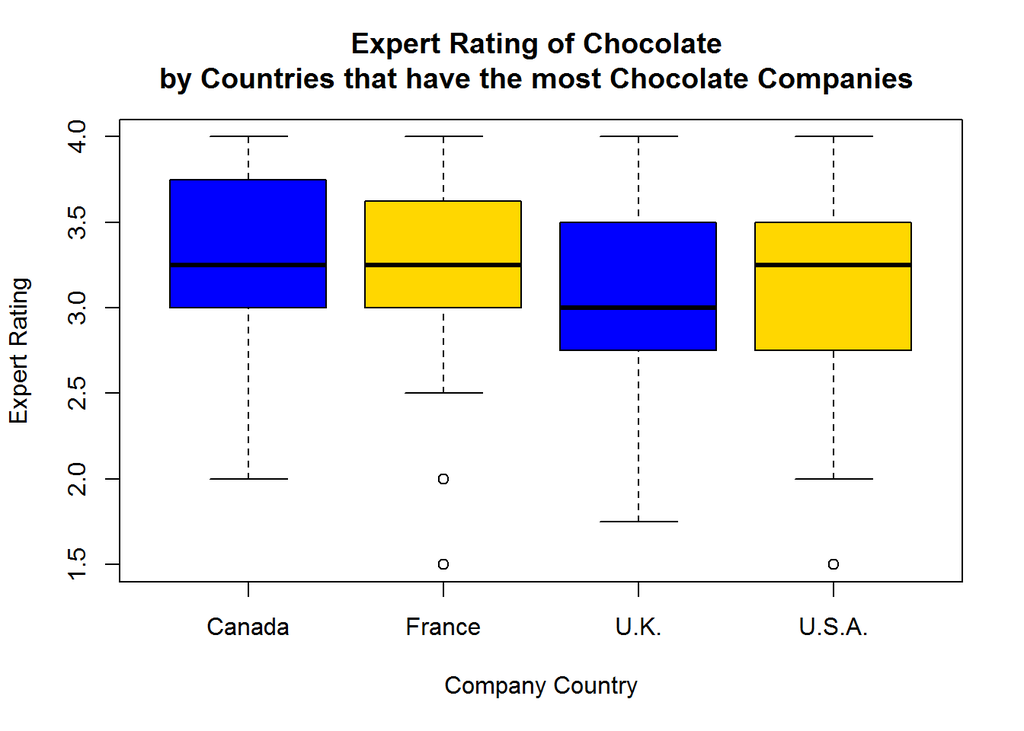

```r
boxplot(Rating~ Location, data=mychoc, ylab="Expert Rating", xlab="Company Country", main="Expert Rating of Chocolate \nby Countries that have the most Chocolate Companies ", col=c("blue","gold"))
```

```r
pander(favstats(Rating~ Location, data=mychoc))
```

| Location | min | Q1 | median | Q3 | max | mean | sd | n | missing |
| --- | --- | --- | --- | --- | --- | --- | --- | --- | --- |
| Canada | 2 | 3 | 3.25 | 3.75 | 4 | 3.319 | 0.4209 | 124 | 0 |
| France | 1.5 | 3 | 3.25 | 3.562 | 4 | 3.252 | 0.5466 | 156 | 0 |
| U.K. | 1.75 | 2.75 | 3 | 3.5 | 4 | 3.055 | 0.4936 | 96 | 0 |
| U.S.A. | 1.5 | 2.75 | 3.25 | 3.5 | 4 | 3.154 | 0.442 | 764 | 0 |

Notice that the distributions of the quality of the chocolate bars from different countries do not appear to be the same.

#### Test of Significance

```r
mychoc <- subset(choc, Location %in% c("U.S.A.","Canada","U.K.","France"))
mychoc$Location <- as.factor(mychoc$Location)
pander(kruskal.test(Rating~ Location, data=mychoc))
```

Kruskal-Wallis rank sum test: `Rating` by `Location`

| Test statistic | df | P value |
| --- | --- | --- |
| 26.63 | 3 | 7.05e-06 * * * |

```r
kp<-kruskal.test(Rating~ Location, data=mychoc)$p.value
kp<-format(kp, scientific=FALSE)
```

### Interpretation

#### Conclusion

With a p-value = 0.000007050349, we consider it unlikely that these samples are from the same distribution. We conclude that there is sufficient evidence to claim that not all of these samples are from the same distribution.